# 🔥 Hands-on: Model Hurdle Spasio-Temporal untuk Hotspot Kebakaran Kalimantan

### Belajar metode tesis langkah demi langkah — tanpa perlu latar belakang statistik

> **Sumber:** tesis *"Model Hurdle Spasio-Temporal Berbasis INLA untuk Hotspot Kebakaran Hutan dan Lahan di Kalimantan dengan Efek Lag Iklim"*. **Isi notebook ini:** semua tahap metode tesis dijalankan ulang pada **data simulasi** (jadi kebenarannya kita ketahui dan bisa dicek), disertai bagan alur dan puluhan visualisasi.

### ⚠️ Baca ini dulu (kejujuran metode)

[output not shown]

### 🗺️ Peta perjalanan

| Bagian | Pertanyaan yang dijawab |
| --- | --- |
| 0 | Bagan alur: data masuk lewat mana, keluar jadi apa? |
| 1 | Bagaimana titik-titik api satelit menjadi tabel *sel × bulan*? |
| 2 | Kenapa datanya "aneh": banyak nol **dan** ekor sangat panjang? |
| 3 | Kenapa Poisson gagal, binomial negatif (NB) lebih baik, dan hurdle lebih baik lagi? |
| 4 | Komponen "laten": ruang (BYM2), waktu (AR(1)), musim (RW1 siklik) |
| 5 | Efek iklim berlag (hujan 0–3 bulan lalu) |
| 6 | Komponen bersama (*copy*) antara bagian kejadian & jumlah |
| 7 | Inti INLA: aproksimasi Laplace, dijelaskan dengan contoh mini |
| 8 | Membagi data latih/uji **menurut waktu** & melatih 6 model |
| 9 | Menilai prediksi: CRPS, PIT, kalibrasi, nol, total bulanan, bulan ekstrem |
| 10 | Apakah selisih antar model nyata? (selisih berpasangan + bootstrap blok) |
| 11 | Membaca hasil: efek iklim, peta ruang, musim, waktu |
| 12 | Rangkuman, kesalahan umum, latihan mandiri, kode R-INLA asli |

> 💡 **Cara belajar:** jalankan sel dari atas ke bawah. Di banyak tempat ada kotak **🧪 Coba sendiri** — ubah angkanya dan jalankan ulang untuk merasakan efeknya.

```python
import sys, warnings, time
sys.path.insert(0, ".")
import numpy as np, pandas as pd
import matplotlib.pyplot as plt
from matplotlib.colors import LogNorm
from scipy import stats
from scipy.special import expit, gammaln
warnings.filterwarnings("ignore")
plt.rcParams.update({"figure.dpi": 110, "axes.grid": True, "grid.alpha": .25, "axes.spines.top": False,
                     "axes.spines.right": False, "font.size": 10})
from hurdle_lab import *
from flow import draw_flow
rng = np.random.default_rng(2026)
print("Siap. Semua pustaka termuat.")
```

```
Siap. Semua pustaka termuat.
```

# BAGIAN 0 — Bagan alur data lengkap

Sebelum masuk detail, lihat dulu **peta besarnya**: dari titik api yang direkam satelit sampai kesimpulan akhir. Setiap kotak punya nomor; nomor yang sama dipakai di bagian-bagian notebook di bawah.

**Cara membaca:** biru = data mentah → kuning = pengolahan data → hijau = pemodelan → merah muda = evaluasi → ungu = hasil.

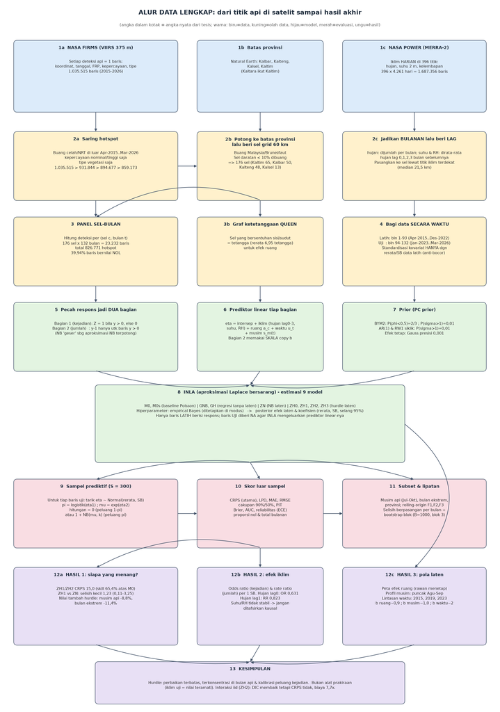

```python
fig = draw_flow("alur_data_lengkap.png")
plt.show()
```

### Ringkasan alur dalam bahasa sehari-hari

1. **Kumpulkan** catatan titik api dari satelit (FIRMS) dan catatan cuaca harian (NASA POWER).
2. **Bersihkan**: ambil hanya deteksi yang meyakinkan, hanya di vegetasi Kalimantan; ubah cuaca harian jadi bulanan; buat "keterlambatan" (hujan 1, 2, 3 bulan lalu).
3. **Kotak-kotakkan** pulau jadi petak 60 × 60 km; **hitung** berapa titik api di setiap petak setiap bulan → *tabel panel* (23.232 baris).
4. **Pisahkan** data lama (untuk belajar) dan data baru (untuk ujian) — **menurut waktu**, bukan acak.
5. **Pecah** hitungan jadi dua pertanyaan: *"ada api atau tidak?"* dan *"kalau ada, berapa banyak?"* (inilah **hurdle**).
6. **Latih** model yang memahami musim, tren waktu, tetangga, dan cuaca (dengan INLA).
7. **Ujikan** pada data baru memakai skor probabilistik, lalu **bandingkan** model secara adil.
8. **Baca** hasilnya: model mana lebih baik, dan *di mana* dan *kapan* ia lebih baik; pola ruang, musim, dan waktu apa yang ditemukan.

# BAGIAN 1 — Dari titik api satelit ke tabel *sel × bulan* (kotak 1–3)

### Konsep

Satelit mencatat **titik** api (koordinat tepat). Tetapi tesis tidak memodelkan titik; ia memodelkan **jumlah titik per petak per bulan**. Analogi: bukan mencatat posisi setiap hujan jatuh, melainkan **berapa mm hujan per kecamatan per bulan**.

Kita buat dunia simulasi: pulau kecil berbentuk Kalimantan, **55 petak**, **108 bulan**.

```python
d = simulate(seed=2026, T=108)
xy, W, n, T = d["xy"], d["W"], d["n"], d["T"]
Y = d["Y"]            # matriks T x n : hitungan hotspot
print(f"Jumlah petak (sel): {n}   Jumlah bulan: {T}   Baris panel: {n*T}")
print(f"Total hotspot: {Y.sum():,}")
print(f"Tetangga queen: rerata {W.sum(1).mean():.2f} per sel  (tesis: 6,95)")
```

```
Jumlah petak (sel): 55   Jumlah bulan: 108   Baris panel: 5940
Total hotspot: 120,540
Tetangga queen: rerata 6.55 per sel  (tesis: 6,95)
```

### 1.1 Dari titik ke petak

Ambil satu bulan puncak. Kita **sebar titik-titik api** secara acak di dalam setiap petak sesuai hitungannya (agar terlihat bagaimana titik berubah jadi angka per petak).

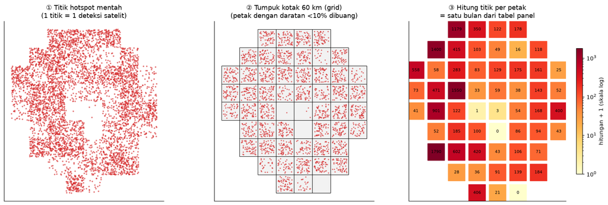

```python
t_peak = int(np.argmax(Y.sum(1)))
rng2 = np.random.default_rng(1)
fig, ax = plt.subplots(1, 3, figsize=(16, 5.2))
# (a) titik mentah
for i in range(n):
    k = min(int(Y[t_peak, i]), 150)   # batasi agar gambar tidak penuh
    px = xy[i, 0] + rng2.uniform(-.5, .5, k); py = xy[i, 1] + rng2.uniform(-.5, .5, k)
    ax[0].scatter(px, py, s=3, c="#d62728", alpha=.5)
ax[0].set_title("① Titik hotspot mentah\n(1 titik = 1 deteksi satelit)")
# (b) grid + batas
for i in range(n):
    ax[1].add_patch(plt.Rectangle((xy[i,0]-.5, xy[i,1]-.5), 1, 1, fc="#f2f2f2", ec="k", lw=.7))
    pts = xy[i] + rng2.uniform(-.4,.4,(min(int(Y[t_peak,i]),60),2)); ax[1].scatter(pts[:,0], pts[:,1], s=2, c="#d62728", alpha=.5)
ax[1].set_title("② Tumpuk kotak 60 km (grid)\n(petak dengan daratan <10% dibuang)")
# (c) hitungan
sc = ax[2].scatter(xy[:,0], xy[:,1], c=Y[t_peak]+1, s=900, marker="s", cmap="YlOrRd", norm=LogNorm())
for i in range(n): ax[2].text(xy[i,0], xy[i,1], int(Y[t_peak,i]), ha="center", va="center", fontsize=7)
ax[2].set_title("③ Hitung titik per petak\n= satu bulan dari tabel panel")
for a in ax: a.set_aspect("equal"); a.set_xticks([]); a.set_yticks([]); a.grid(False)
plt.colorbar(sc, ax=ax[2], label="hitungan + 1 (skala log)", shrink=.7)
plt.tight_layout(); plt.show()
```

### 1.2 Tabel panel

Diulang untuk setiap bulan, hasilnya adalah tabel panjang. **Satu baris = satu petak di satu bulan.** Inilah data yang dimodelkan.

```python
panel = pd.DataFrame({
    "sel": np.tile(np.arange(n), T), "bulan_ke": np.repeat(np.arange(1, T+1), n),
    "bulan_kalender": np.repeat(d["month"] + 1, n),
    "hotspot": Y.reshape(-1),
    "hujan_lag0": d["X_raw"]["hujan_lag0"].reshape(-1), "hujan_lag1": d["X_raw"]["hujan_lag1"].reshape(-1),
    "hujan_lag2": d["X_raw"]["hujan_lag2"].reshape(-1), "hujan_lag3": d["X_raw"]["hujan_lag3"].reshape(-1),
    "suhu": d["X_raw"]["suhu"].reshape(-1), "RH": d["X_raw"]["kelembapan"].reshape(-1)}).round(1)
print(f"Panel: {panel.shape[0]:,} baris (tesis: 23.232 = 176 sel × 132 bulan)")
panel.sample(8, random_state=3)
```

```
Panel: 5,940 baris (tesis: 23.232 = 176 sel × 132 bulan)
```

|  | sel | bulan_ke | bulan_kalender | hotspot | hujan_lag0 | hujan_lag1 | hujan_lag2 | hujan_lag3 | suhu | RH |
| --- | --- | --- | --- | --- | --- | --- | --- | --- | --- | --- |
| 3723 | 38 | 68 | 8 | 4 | 103.4 | 108.7 | 267.8 | 245.7 | 26.9 | 82.9 |
| 1476 | 46 | 27 | 3 | 0 | 262.8 | 274.3 | 352.5 | 328.3 | 24.9 | 88.8 |
| 1125 | 25 | 21 | 9 | 52 | 19.4 | 10.4 | 4.9 | 73.8 | 27.1 | 78.6 |
| 115 | 5 | 3 | 3 | 0 | 374.8 | 446.6 | 448.5 | 493.1 | 25.8 | 84.1 |
| 4491 | 36 | 82 | 10 | 0 | 109.4 | 136.0 | 145.4 | 100.9 | 26.4 | 81.8 |
| 2556 | 26 | 47 | 11 | 1 | 94.4 | 147.9 | 83.2 | 101.0 | 26.2 | 79.5 |
| 3811 | 16 | 70 | 10 | 15 | 207.4 | 180.0 | 240.8 | 284.4 | 25.8 | 86.9 |
| 2494 | 19 | 46 | 10 | 28 | 80.6 | 116.5 | 109.0 | 85.2 | 26.4 | 78.8 |

# BAGIAN 2 — Mengenal data: kenapa "aneh"? (kotak 3 → analisis deskriptif)

Tesis menemukan **tiga sifat** yang sulit ditangani satu distribusi sekaligus:

1. **Banyak nol** (tesis: 39,94% sel-bulan nol)
2. **Nolnya bukan acak**, melainkan musiman dan berbeda antarwilayah
3. **Ekor sangat berat**: median hanya 5, tapi maksimum 11.334

Kita cek ketiganya di data simulasi.

```python
y = Y.reshape(-1)
pos = y[y > 0]
print(f"Proporsi nol            : {np.mean(y==0)*100:5.1f}%   (tesis 39,94%)")
print(f"Rerata hitungan         : {y.mean():6.2f}   (tesis 35,59)")
print(f"Rasio ragam / rerata    : {y.var()/y.mean():6.1f}   (tesis 1.766,6; Poisson menuntut = 1)")
print(f"Median hitungan positif : {np.median(pos):6.1f}   (tesis 5)")
print(f"Kuantil 99% (positif)   : {np.percentile(pos,99):6.0f}   (tesis ≈965)")
print(f"Maksimum                : {y.max():6d}   (tesis 11.334)")
tot_m = Y.sum(1); top6 = np.sort(tot_m)[::-1][:6].sum()/tot_m.sum()
print(f"6 bulan teratas = {top6*100:.1f}% dari semua hotspot  (tesis 58,2%)")
```

```
Proporsi nol            :  45.1%   (tesis 39,94%)
Rerata hitungan         :  20.29   (tesis 35,59)
Rasio ragam / rerata    :  353.3   (tesis 1.766,6; Poisson menuntut = 1)
Median hitungan positif :    8.0   (tesis 5)
Kuantil 99% (positif)   :    515   (tesis ≈965)
Maksimum                :   2156   (tesis 11.334)
6 bulan teratas = 50.2% dari semua hotspot  (tesis 58,2%)
```

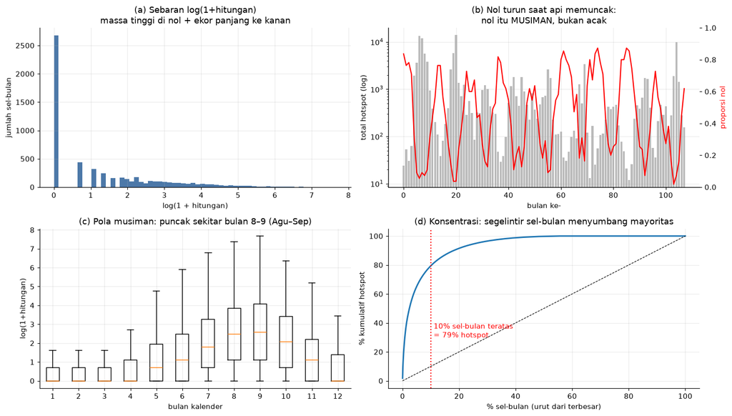

```python
fig, ax = plt.subplots(2, 2, figsize=(14, 8))
# (a) histogram log
ax[0,0].hist(np.log1p(y), bins=60, color="#4c78a8")
ax[0,0].set_title("(a) Sebaran log(1+hitungan)\nmassa tinggi di nol + ekor panjang ke kanan")
ax[0,0].set_xlabel("log(1 + hitungan)"); ax[0,0].set_ylabel("jumlah sel-bulan")
# (b) proporsi nol per bulan + total
zero_m = (Y == 0).mean(1)
ax[0,1].bar(range(T), tot_m, color="#bbbbbb", label="total hotspot")
ax[0,1].set_yscale("log"); ax[0,1].set_ylabel("total hotspot (log)")
a2 = ax[0,1].twinx(); a2.plot(range(T), zero_m, "r-", label="proporsi nol"); a2.set_ylim(0,1); a2.grid(False)
a2.set_ylabel("proporsi nol", color="r")
ax[0,1].set_title("(b) Nol turun saat api memuncak:\nnol itu MUSIMAN, bukan acak"); ax[0,1].set_xlabel("bulan ke-")
# (c) musiman kalender
mm = pd.DataFrame({"bln": np.repeat(d["month"]+1, n), "y": y})
box = [mm.y[mm.bln==b].values for b in range(1,13)]
ax[1,0].boxplot([np.log1p(b) for b in box], tick_labels=list(range(1,13)), showfliers=False)
ax[1,0].set_title("(c) Pola musiman: puncak sekitar bulan 8–9 (Agu–Sep)")
ax[1,0].set_xlabel("bulan kalender"); ax[1,0].set_ylabel("log(1+hitungan)")
# (d) Lorenz: konsentrasi
srt = np.sort(y)[::-1]; cum = np.cumsum(srt)/srt.sum()
ax[1,1].plot(np.arange(1, len(y)+1)/len(y)*100, cum*100, lw=2)
ax[1,1].plot([0,100],[0,100],"k--",lw=.8)
ax[1,1].axvline(10, color="r", ls=":"); ax[1,1].text(11, 30, f"10% sel-bulan teratas\n= {cum[int(.1*len(y))]*100:.0f}% hotspot", color="r")
ax[1,1].set_title("(d) Konsentrasi: segelintir sel-bulan menyumbang mayoritas"); ax[1,1].set_xlabel("% sel-bulan (urut dari terbesar)"); ax[1,1].set_ylabel("% kumulatif hotspot")
plt.tight_layout(); plt.show()
```

### 💡 Poin penting: ini **bukan** "pencilan"

Banyak orang menyebut ini *"banyak nol dan banyak pencilan"*. Tesis **mengoreksi** pembacaan itu:

- Nilai besar di bulan kering **bukan galat** — itu bagian sah dari data dan justru yang **terpenting** untuk pemantauan.
- Menghapus atau "meredamnya" akan membuang informasi yang paling dicari.
- Masalah sebenarnya adalah **dua hal berbeda yang tercampur**: *apakah ada deteksi?* dan *berapa banyak jika ada?*

### 2.2 Peta: nol juga bergantung lokasi

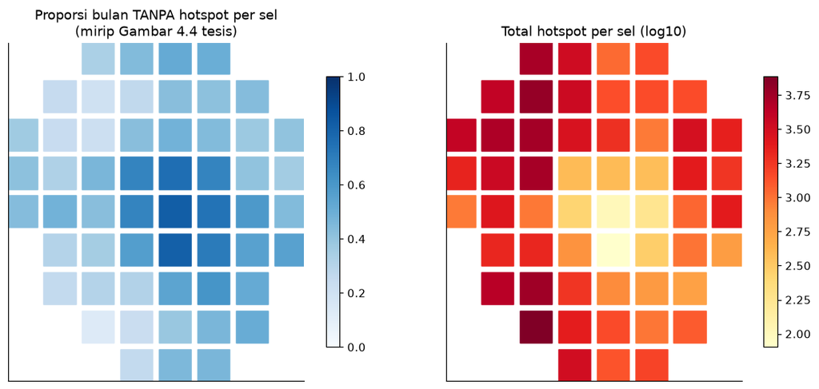

```python
fig, ax = plt.subplots(1, 2, figsize=(11, 4.8))
z_cell = (Y == 0).mean(0)
s1 = ax[0].scatter(xy[:,0], xy[:,1], c=z_cell, s=800, marker="s", cmap="Blues", vmin=0, vmax=1)
ax[0].set_title("Proporsi bulan TANPA hotspot per sel\n(mirip Gambar 4.4 tesis)"); plt.colorbar(s1, ax=ax[0], shrink=.8)
s2 = ax[1].scatter(xy[:,0], xy[:,1], c=np.log10(Y.sum(0)+1), s=800, marker="s", cmap="YlOrRd")
ax[1].set_title("Total hotspot per sel (log10)"); plt.colorbar(s2, ax=ax[1], shrink=.8)
for a in ax: a.set_aspect("equal"); a.grid(False); a.set_xticks([]); a.set_yticks([])
plt.tight_layout(); plt.show()
```

### 2.3 Apakah sel bertetangga mirip? — Indeks Moran

Indeks Moran mengukur: *"sel yang bersebelahan, apakah nilainya mirip?"* Nilai > 0 = mirip (menggerombol). Tesis: selalu positif (0,105–0,861) → graf ketetanggaan masuk akal dipakai.

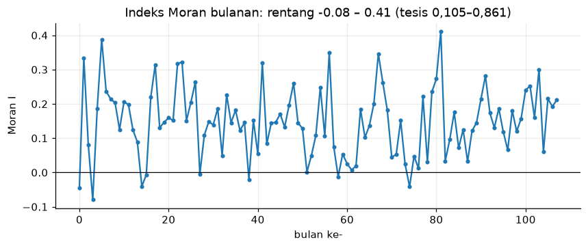

```python
def moran(x, W):
    z = x - x.mean()
    return len(x) / W.sum() * (z @ W @ z) / (z @ z)
mor = [moran(np.log1p(Y[t]), W) for t in range(T)]
fig, ax = plt.subplots(figsize=(9, 3.2))
ax.plot(mor, "o-", ms=3); ax.axhline(0, color="k", lw=.8)
ax.set_title(f"Indeks Moran bulanan: rentang {min(mor):.2f} – {max(mor):.2f} (tesis 0,105–0,861)"); ax.set_xlabel("bulan ke-"); ax.set_ylabel("Moran I")
plt.show()
```

# BAGIAN 3 — Dari Poisson ke binomial negatif ke hurdle (kotak 5)

## 3.2 Binomial negatif (NB): lebih lentur

NB menambah satu pengatur, **ukuran k** (*size*). Makin kecil k, makin "melebar" (overdispersi): ragam = μ + μ²/k. Peluang nol pada NB: **P(Y=0) = (k/(k+μ))^k**.

Geser parameternya dan lihat bentuknya:

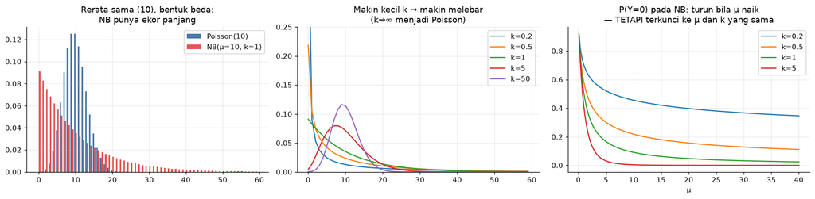

```python
from scipy.stats import poisson, nbinom
def nb_pmf(y, mu, k):  # parameter: rerata mu dan ukuran k
    p = k / (k + mu); return nbinom.pmf(y, k, p)
ys = np.arange(0, 60)
fig, ax = plt.subplots(1, 3, figsize=(16, 4))
mu = 10
ax[0].bar(ys-.2, poisson.pmf(ys, mu), .4, label="Poisson(10)", color="#4c78a8")
ax[0].bar(ys+.2, nb_pmf(ys, mu, 1.0), .4, label="NB(μ=10, k=1)", color="#e45756")
ax[0].set_title("Rerata sama (10), bentuk beda:\nNB punya ekor panjang"); ax[0].legend()
for k in [0.2, 0.5, 1, 5, 50]:
    ax[1].plot(ys, nb_pmf(ys, mu, k), label=f"k={k}")
ax[1].set_title("Makin kecil k → makin melebar\n(k→∞ menjadi Poisson)"); ax[1].legend(); ax[1].set_ylim(0, .25)
mus = np.linspace(.1, 40, 200)
for k in [0.2, 0.5, 1, 5]:
    ax[2].plot(mus, (k/(k+mus))**k, label=f"k={k}")
ax[2].set_title("P(Y=0) pada NB: turun bila μ naik\n— TETAPI terkunci ke μ dan k yang sama"); ax[2].set_xlabel("μ"); ax[2].legend()
plt.tight_layout(); plt.show()
```

> **🧪 Coba sendiri:** ubah `mu = 10` jadi `2` atau `40`. Perhatikan bahwa pada μ kecil NB sudah menghasilkan banyak nol *sendirian* — itulah mengapa tesis menekankan bahwa lawan yang adil bagi hurdle adalah **NB berstruktur laten sama (ZN)**, bukan sekadar Poisson.

### Masalah NB tunggal

Satu NB **mengikat** peluang nol dan besarnya hitungan ke parameter yang sama. Padahal bisa jadi:

- *apakah ada deteksi* dikendalikan oleh satu hal (misal hujan bulan ini), dan
- *berapa banyak deteksi* dikendalikan hal lain (misal hujan 1–2 bulan lalu, kelembapan).